# Assignment 2: Physical Properties of Lakes

Ethan Ready

## OVERVIEW

This exercise accompanies the lessons in Hydrologic Data Analysis on the physical properties of lakes.

## Directions

1. Change “Student Name” on line 3 (above) with your name.
2. Work through the steps, **creating code and output** that fulfill each instruction.
3. Be sure to **answer the questions** in this assignment document.
4. When you have completed the assignment, **Knit** the text and code into a single PDF file.
5. After Knitting, submit the completed exercise (PDF file) to the dropbox in Sakai. Add your last name into the file name (e.g., “Salk_A02_LakePhysical.Rmd”) prior to submission.

The completed exercise is due on 11 September 2019 at 9:00 am.

## Setup

1. Verify your working directory is set to the R project file,
2. Load the tidyverse, lubridate, and cowplot packages
3. Import the NTL-LTER physical lake dataset and set the date column to the date format
4. Set your ggplot theme (can be theme_classic or something else)

```r
getwd()
```

```
## [1] "/Users/ethanready/Hydrologic_Data_Analysis/Assignments"
```

```r
library(tidyverse)
library(lubridate)
```

```r
library(cowplot)
filename<-file.path(path.expand("~"), "Hydrologic_Data_Analysis", "Data", "Raw","NTL-LTER_Lake_ChemistryPhysics_Raw.csv")
NTLdata<-read.csv(filename)
NTLdata$sampledate<-as.Date(NTLdata$sampledate, "%m/%d/%y")

theme_set(theme_classic())
```

## Creating and analyzing lake temperature profiles

### Single lake, multiple dates

5. Choose either Peter or Tuesday Lake. Create a new data frame that wrangles the full data frame so that it only includes that lake during two different years (one year from the early part of the dataset and one year from the late part of the dataset).

```r
Peter.data<-filter(NTLdata, lakename=="Peter Lake", year4 == 1985 | year4==2015)
```

6. Create three graphs: (1) temperature profiles for the early year, (2) temperature profiles for the late year, and (3) a `plot_grid` of the two graphs together. Choose `geom_point` and color your points by date.

Remember to edit your graphs so they follow good data visualization practices.

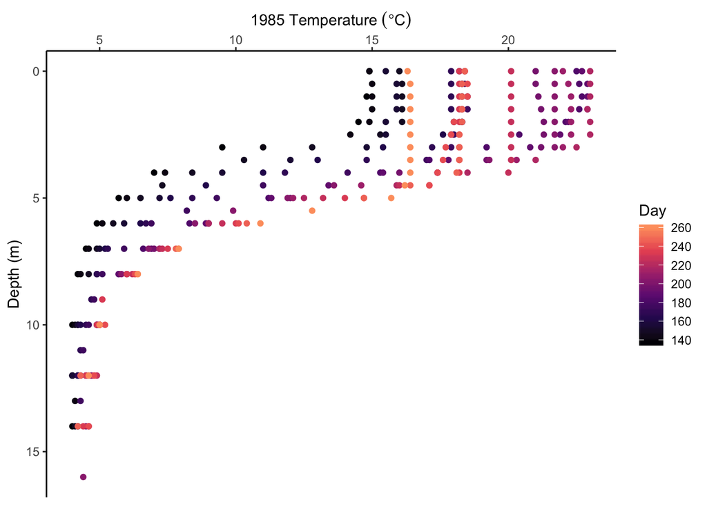

```r
peter1985<-filter(Peter.data, year4==1985)%>%
  ggplot(aes(x = temperature_C, y = depth, color = daynum)) +
  geom_point() +
  scale_y_reverse() +
  scale_x_continuous(position = "top") +
  scale_color_viridis_c(end = 0.8, option = "magma") +
  labs(x = expression("1985 Temperature "(degree*C)), y = "Depth (m)", color="Day")

peter2015<-filter(Peter.data, year4==2015)%>%
  ggplot(aes(x = temperature_C, y = depth, color = daynum)) +
  geom_point() +
  scale_y_reverse() +
  scale_x_continuous(position = "top") +
  scale_color_viridis_c(end = 0.8, option = "magma") +
  labs(x = expression("2015 Temperature "(degree*C)), y = "Depth (m)", color= "Day")

print(peter1985)
```

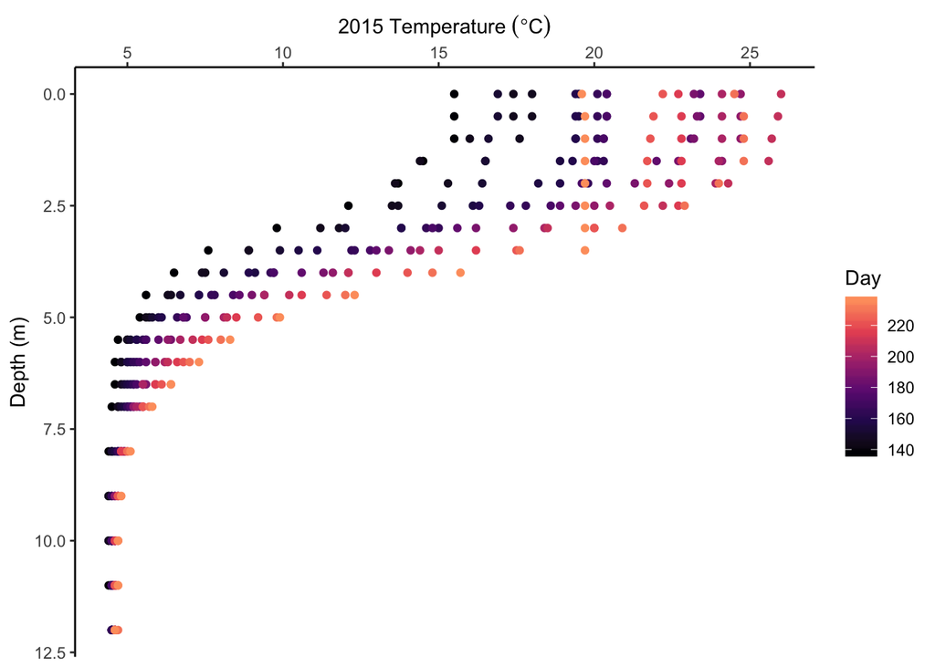

```r
print(peter2015)
```

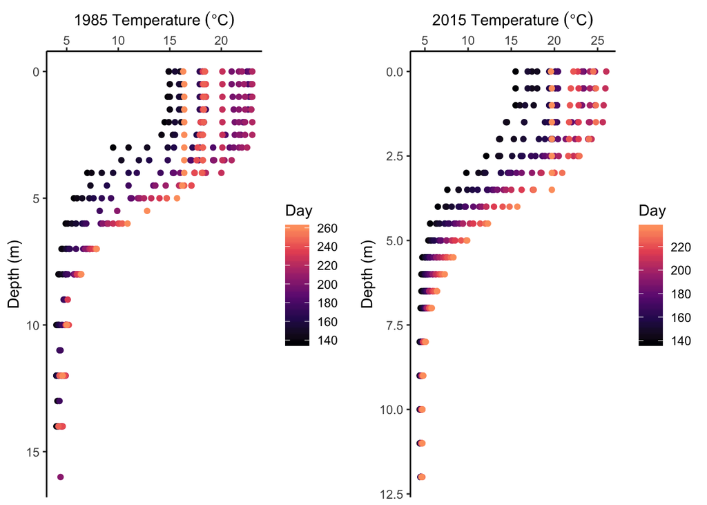

```r
plot_grid(peter1985, peter2015)
```

7. Interpret the stratification patterns in your graphs in light of seasonal trends. In addition, do you see differences between the two years?

> The deeper waters stay around 5 degree*C the whole year, as they interact less with the atmosphere. The warming atmosphere heats the surface waters throughout the summer, with the water from 0-2m below the surface experiencing the greatest warming. Surface temperatures cool back down as the summer winds down and solar intensity decreases. Peter Lake appears to have reached higher maximum temperatures in the summer of 2015 than in the summer of 1985.

### Multiple lakes, single date

8. On July 25, 26, and 27 in 2016, all three lakes (Peter, Paul, and Tuesday) were sampled. Wrangle your data frame to include just these three dates.

```r
three.dates<-filter(NTLdata, sampledate=="2016-7-27"|sampledate=="2016-7-26"|sampledate=="2016-7-25")
```

9. Plot a profile line graph of temperature by depth, one line per lake. Each lake can be designated by a separate color.

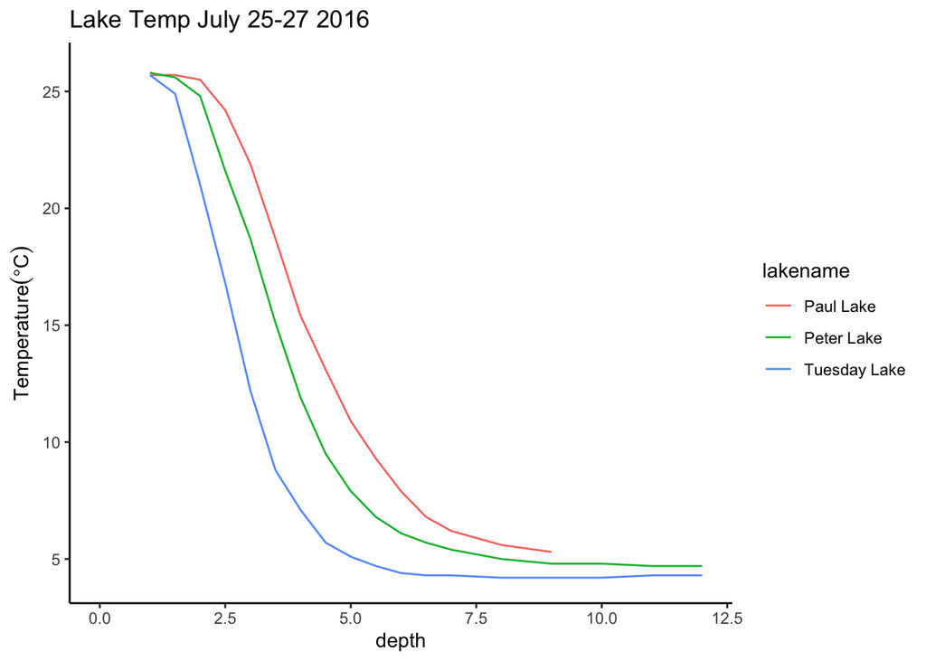

```r
ggplot(three.dates, aes(y=temperature_C, x=depth, color=lakename))+
  geom_line()+
  labs(y=expression("Temperature"(degree*C)), title = "Lake Temp July 25-27 2016")
```

10. What is the depth range of the epilimnion in each lake? The thermocline? The hypolimnion?

> Epiliminion: Between 2m (Tuesday) and 3m(Paul), Thermocline: 6m(Tuesday)-7m(Paul), Hypolimion: whatever the depth of the lake is, with Peter and Tuesday reaching 12m.

## Trends in surface temperatures over time.

11. Run the same analyses we ran in class to determine if surface lake temperatures for a given month have increased over time (“Long-term change in temperature” section of day 4 lesson in its entirety), this time for either Peter or Tuesday Lake.

```r
Peter.surf<-mutate(Peter.data, "Month"=month(sampledate))
Peter.surf<-filter(Peter.surf, depth==0.00, 9>Month, Month>4)

Petersurf.may<- filter(Peter.surf, Month==5)
Petersurf.jun<- filter(Peter.surf, Month==6)
Petersurf.jul<- filter(Peter.surf, Month==7)
Petersurf.aug<- filter(Peter.surf, Month==8)

lm.may<-lm(temperature_C~year4, data=Petersurf.may)
lm.jun<-lm(temperature_C~year4, data=Petersurf.jun)
lm.jul<-lm(temperature_C~year4, data=Petersurf.jul)
lm.aug<-lm(temperature_C~year4, data=Petersurf.aug)

print("Degree increase predicted in May")
```

```
## [1] "Degree increase predicted in May"
```

```r
lm.may$coefficients["year4"]*32
```

```
##    year4
## 1.813333
```

```r
print("Degree increase predicted in Jun")
```

```
## [1] "Degree increase predicted in Jun"
```

```r
lm.jun$coefficients["year4"]*32
```

```
##    year4
## 2.681905
```

```r
print("Degree increase predicted in Jul")
```

```
## [1] "Degree increase predicted in Jul"
```

```r
lm.jul$coefficients["year4"]*32
```

```
## year4
## 2.688
```

```r
print("Degree increase predicted in Aug")
```

```
## [1] "Degree increase predicted in Aug"
```

```r
lm.aug$coefficients["year4"]*32
```

```
## year4
##  2.48
```

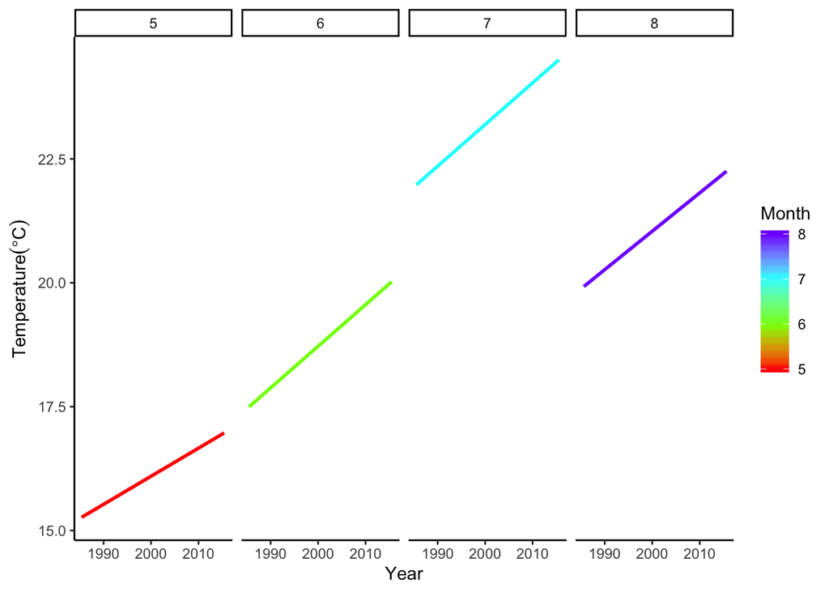

```r
ggplot(Peter.surf, aes(x=sampledate, y=temperature_C, color=Month))+
  facet_grid(cols=vars(Month))+
  geom_smooth(se=FALSE, method=lm)+
  labs(x="Year", y=expression("Temperature"(degree*C)))+
  scale_color_gradientn(colours=rainbow(4))
```

12. How do your results compare to those we found in class for Paul Lake? Do similar trends exist for both lakes?

> My results for Peter Lake show surface warming trends over all 4 months during the last 30 years. These are similar to the trends observed for Paul Lake.